# Pipes

Alex Montgomery

10/03/2022

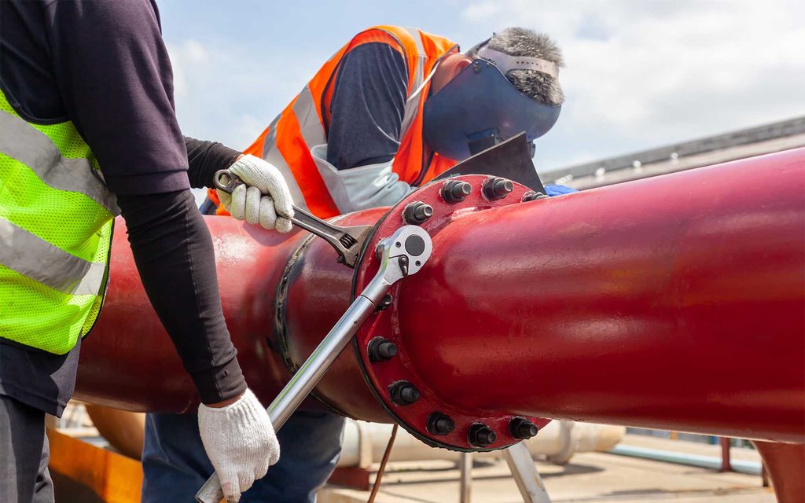

## Pipes Dataset

The following dataset that shall be explored contains work orders from a utility company. The data represents jobs performed on pipes belonging to the company.

```r
#Load the data set
dfraw = read.csv("data/raw/example.work.orders.csv")
#Check the data is as expected
head(dfraw, 5)
```

```
##   JOB_ID JOB_TYPE DEPTH_M DIAMETER_MM MATERIAL LENGTH_M  JOB_COST
## 1  Job 1  Replace    2.19         200       ST    31.55 19847.644
## 2  Job 2  Replace    2.27          63       AC    15.14  4476.589
## 3  Job 3   Repair    3.64         450       ST    15.17 16871.485
## 4  Job 4  Replace    2.28         200       AC    15.64 11158.144
## 5  Job 5  Replace    2.40         200       ST    39.23 16913.612
```

```r
#Check the structure of the data
str(dfraw)
```

```
## 'data.frame':    5000 obs. of  7 variables:
##  $ JOB_ID     : chr  "Job 1" "Job 2" "Job 3" "Job 4" ...
##  $ JOB_TYPE   : chr  "Replace" "Replace" "Repair" "Replace" ...
##  $ DEPTH_M    : num  2.19 2.27 3.64 2.28 2.4 4.32 3.34 3.19 3.3 2.01 ...
##  $ DIAMETER_MM: int  200 63 450 200 200 200 50 50 200 90 ...
##  $ MATERIAL   : chr  "ST" "AC" "ST" "AC" ...
##  $ LENGTH_M   : num  31.6 15.1 15.2 15.6 39.2 ...
##  $ JOB_COST   : num  19848 4477 16871 11158 16914 ...
```

It is important to check the structure of the data to, firstly, get to know the data better, but also to ensure each variable is the correct data type. For example, ensuring a numerical variable hasn’t been coded as a string.

## Codebook

| Variable Title | Explanation |
| --- | --- |
| JOB_ID | The unique identity of the work order |
| JOB_TYPE | The type of job performed |
| DEPTH_M | The depth of the pipe (m) |
| DIAMETER MM | The diameter of the pipe (mm) |
| MATERIAL | The material of the pipe |
| LENGTH_M | The length of the pipe (m) |
| JOB_COST | The cost of the job (£) |

## Data Cleansing

- Examining the descriptive statistics of a dataset can help identify outliers and data input errors.
- In this dataset, diameter appears to have an unlikely maximum value of 999999 mm.
- The minimum value of depth also indicates a possible data input error with the value being a negative number.

```r
#Output descriptive statistics for all variables
summary(dfraw)
```

```
##     JOB_ID            JOB_TYPE            DEPTH_M       DIAMETER_MM
##  Length:5000        Length:5000        Min.   :-4.66   Min.   :    50
##  Class :character   Class :character   1st Qu.: 2.00   1st Qu.:    63
##  Mode  :character   Mode  :character   Median : 2.57   Median :    90
##                                        Mean   : 2.67   Mean   :   733
##                                        3rd Qu.: 3.27   3rd Qu.:   200
##                                        Max.   : 4.98   Max.   :999999
##
##    MATERIAL            LENGTH_M        JOB_COST
##  Length:5000        Min.   : 8.16   Min.   :  586.5
##  Class :character   1st Qu.:17.81   1st Qu.: 3978.9
##  Mode  :character   Median :23.79   Median : 6986.9
##                     Mean   :25.14   Mean   :10207.7
##                     3rd Qu.:31.66   3rd Qu.:12884.6
##                     Max.   :49.71   Max.   :85860.1
##                                     NA's   :6
```

```r
#Remove missing data
dfraw <- na.omit(dfraw)

#Sort data by Diameter
dfraw <- dfraw[order(-dfraw$DIAMETER_MM),]
head(dfraw, 5)
```

```
##        JOB_ID JOB_TYPE DEPTH_M DIAMETER_MM MATERIAL LENGTH_M  JOB_COST
## 1111 Job 1111   Repair    3.49      999999       AC    14.22  2780.958
## 3333 Job 3333   Repair    3.08      999999       AC    25.00  3692.562
## 4444 Job 4444  Replace    2.52      999999       AC    27.65 12705.233
## 3       Job 3   Repair    3.64         450       ST    15.17 16871.485
## 19     Job 19   Repair    2.72         450       CI    19.72 16618.354
```

```r
#Remove observations with diameters above maximum set diameter
maximum_diamater <- 10000

cleandf <- subset(dfraw, DIAMETER_MM < maximum_diamater)

#Remove observations with negative values of depth
cleandf <- subset(cleandf, DEPTH_M > 0)

#Convert JOB_TYPE to a factor and add to the dataset
cleandf$JOB_TYPE <- as.factor(cleandf$JOB_TYPE)
#Ensure JOB_TYPE is a factor data type
class(cleandf$JOB_TYPE)
```

```
## [1] "factor"
```

```r
#Convert MATERIAL to a factor and add to the dataset
cleandf$MATERIAL <- as.factor(cleandf$MATERIAL)
#Ensure MATERIAL is a factor data type
class(cleandf$MATERIAL)
```

```
## [1] "factor"
```

# 1. Describe the data provided.

## Visualising the data

Visualising a dataset with histograms and bar charts often helps get a better understanding of the data. In this case, it appears that the 4 continuous variables all have a positive skew. Diameter appears to have clusters of data which suggests the piping company have preset diameters that are produced.

```r
#Check the descriptive statistics after cleaning the data
summary(cleandf)
```

```
##     JOB_ID             JOB_TYPE       DEPTH_M       DIAMETER_MM    MATERIAL
##  Length:4989        Repair :1488   Min.   :1.000   Min.   : 50.0   AC:2554
##  Class :character   Replace:3501   1st Qu.:2.010   1st Qu.: 63.0   CI:1430
##  Mode  :character                  Median :2.570   Median : 90.0   ST:1005
##                                    Mean   :2.673   Mean   :133.1
##                                    3rd Qu.:3.270   3rd Qu.:200.0
##                                    Max.   :4.980   Max.   :450.0
##     LENGTH_M        JOB_COST
##  Min.   : 8.16   Min.   :  586.5
##  1st Qu.:17.81   1st Qu.: 3979.2
##  Median :23.78   Median : 6985.3
##  Mean   :25.13   Mean   :10207.5
##  3rd Qu.:31.65   3rd Qu.:12884.9
##  Max.   :49.71   Max.   :85860.1
```

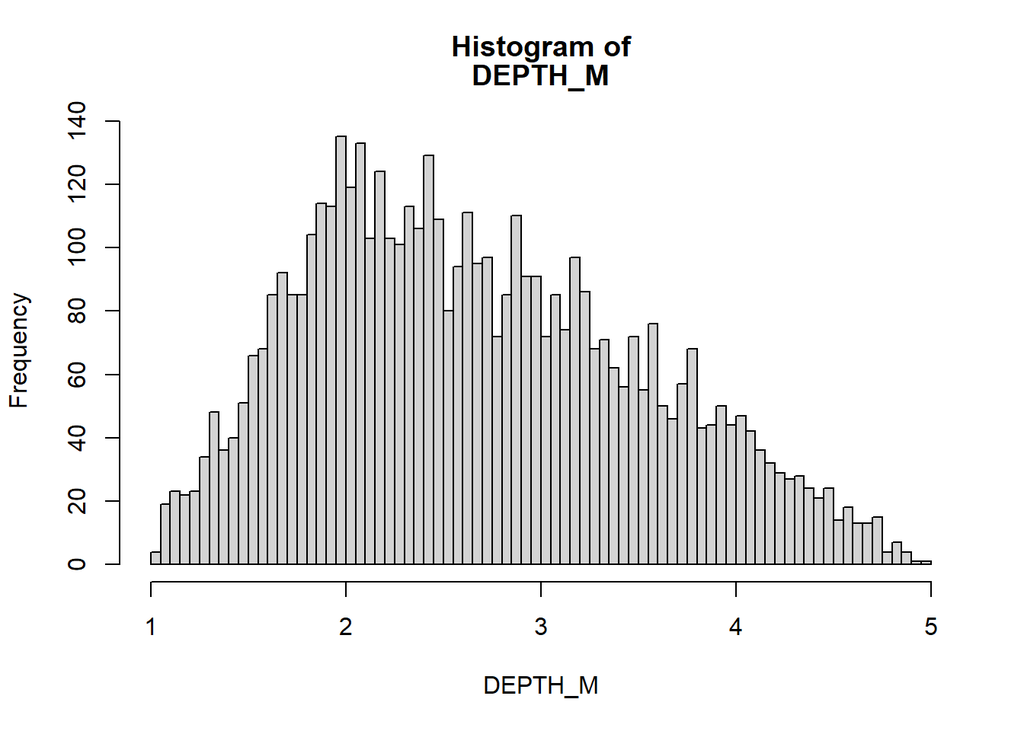

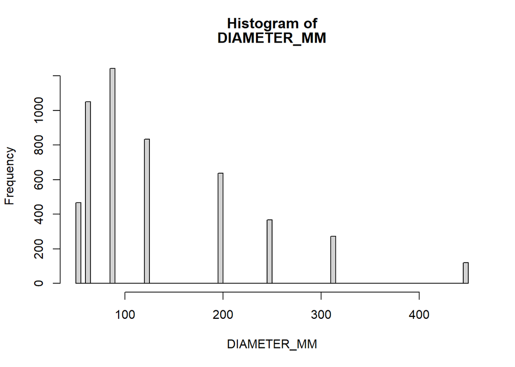

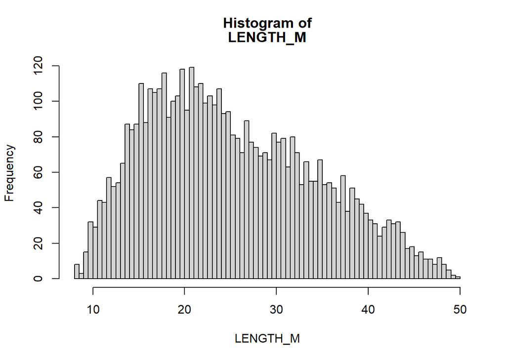

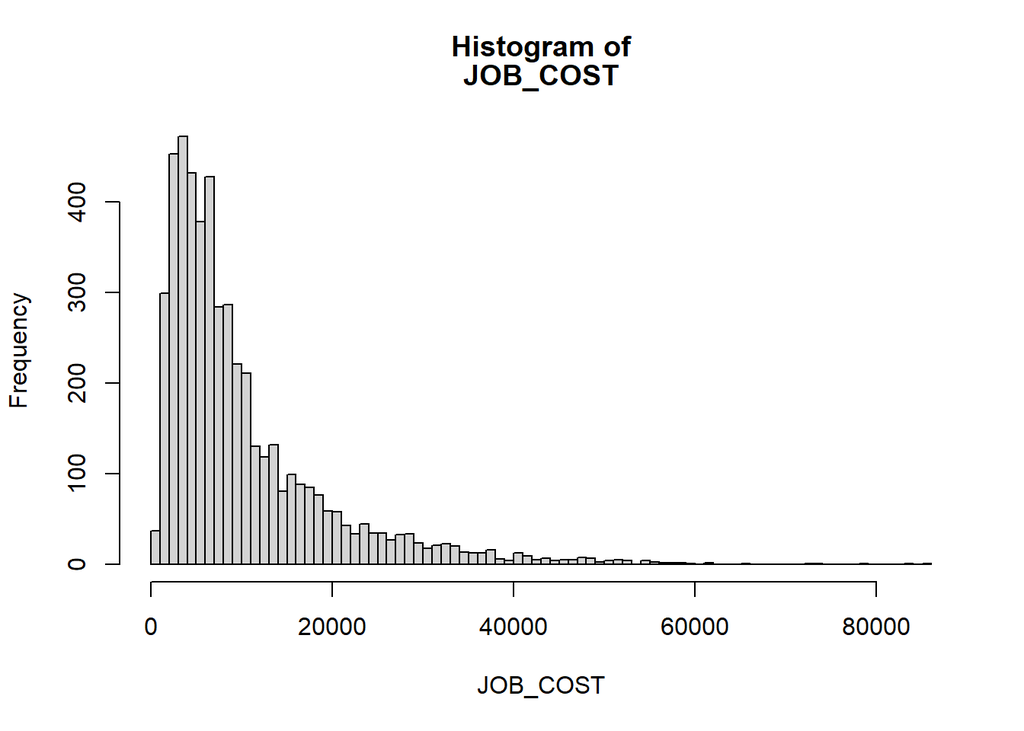

```r
#Create histograms to visualise the continuous variables
variables <- colnames(cleandf[c(3,4,6,7)])

for(i in variables){
hist(cleandf[,i],
        xlab = i,
        main = c("Histogram of", i),
        breaks = sqrt(nrow(cleandf))
        )
  }
```

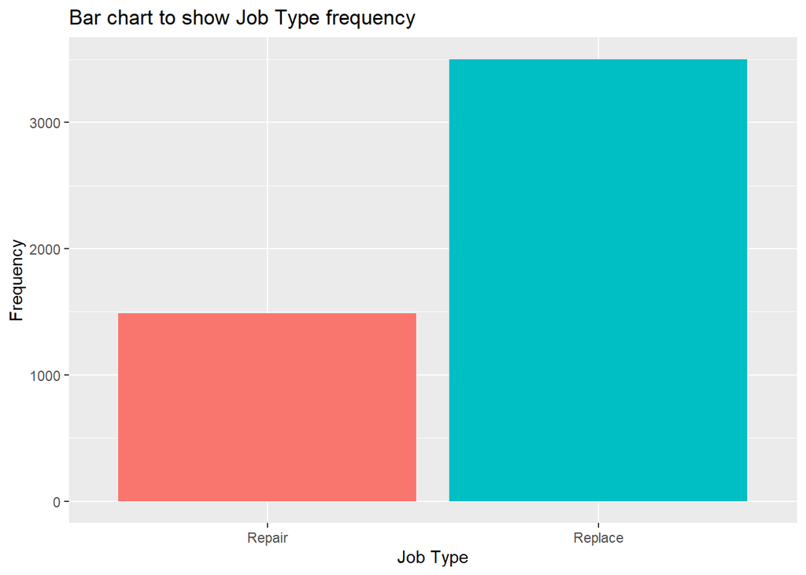

```r
#Create bar charts to visualise the categorical variables
p1 <- ggplot(cleandf, aes(x = JOB_TYPE, fill = JOB_TYPE)) +
  geom_bar() +
  theme(legend.position = "none") +
  labs(y = "Frequency", x = "Job Type") +
  ggtitle("Bar chart to show Job Type frequency ")
p1
```

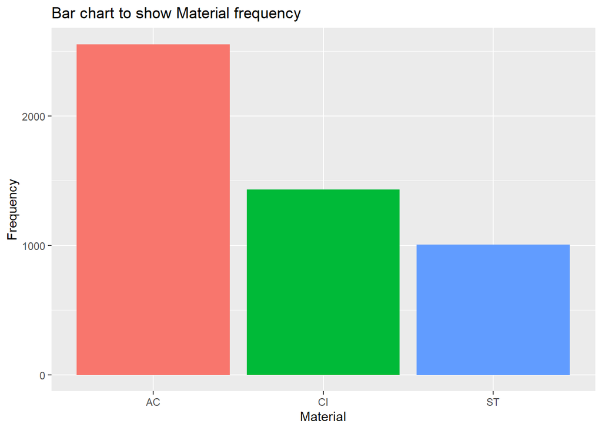

```r
p2 <- ggplot(cleandf, aes(x = MATERIAL, fill = MATERIAL)) +
  geom_bar() +
  theme(legend.position = "none") +
  labs(y = "Frequency", x = "Material") +
  ggtitle("Bar chart to show Material frequency ")
p2
```

# 2. Show how the cost of jobs is related to other features in the data.

## Visualising continous variables

Diameter has a clear positive linear relationship with job cost whereas depth and length have far weaker relationships with job cost

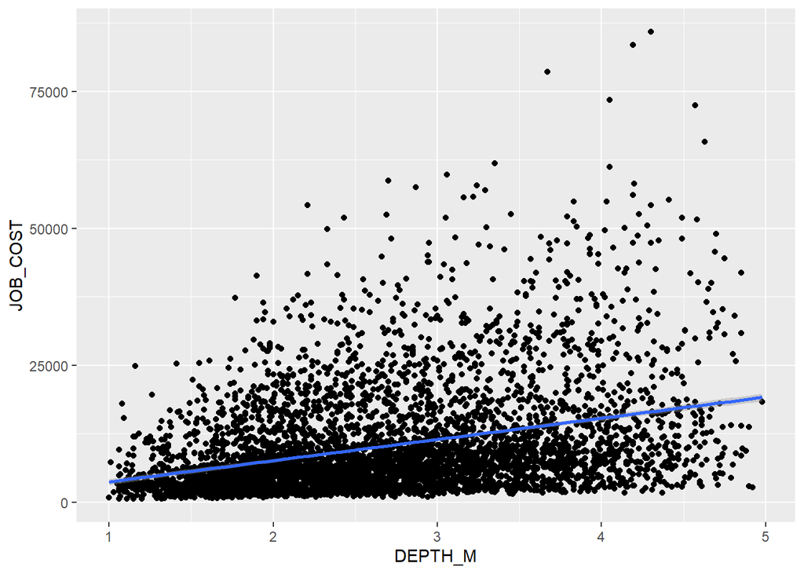

```r
#Plot regression line graph for DEPTH_MM and JOB_COST
p3 <- ggplot(cleandf, aes(x = DEPTH_M, y = JOB_COST)) +
    geom_point() +
    geom_smooth(method = 'lm')
p3
```

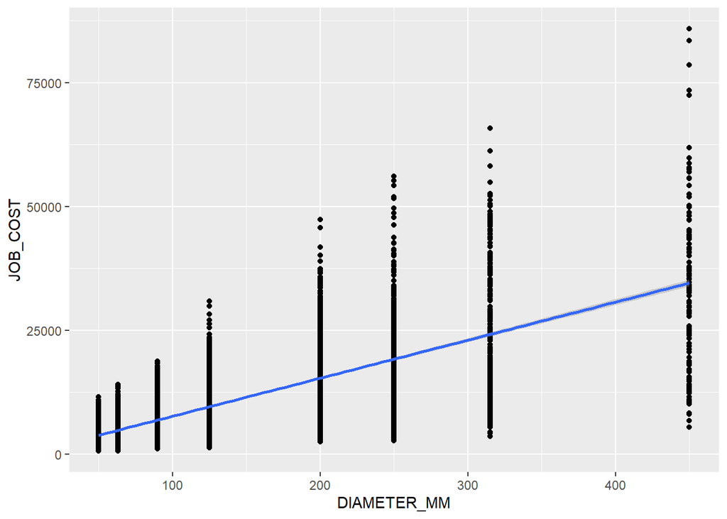

```r
#Plot regression line graph for DIAMTER_MM and JOB_COST
p4 <- ggplot(cleandf, aes(x = DIAMETER_MM, y = JOB_COST)) +
    geom_point() +
    geom_smooth(method = 'lm')
p4
```

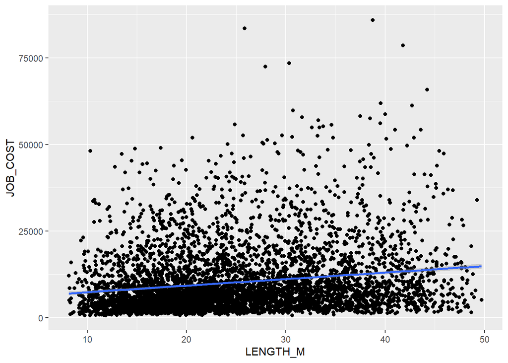

```r
#Plot regression line graph for LENGTH_M and JOB_COST
p5 <- ggplot(cleandf, aes(x = LENGTH_M, y = JOB_COST)) +
    geom_point() +
    geom_smooth(method = 'lm')
p5
```

## Visualising catagorical variables

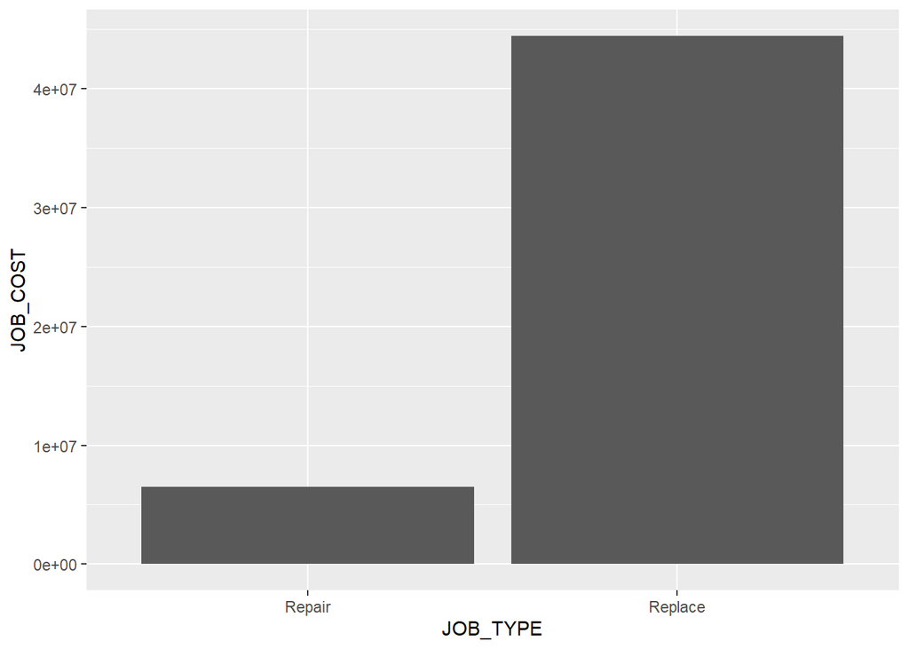

```r
p6 <- ggplot(cleandf, aes(x = JOB_TYPE, y = JOB_COST)) +
      geom_bar(stat = "identity")
p6
```

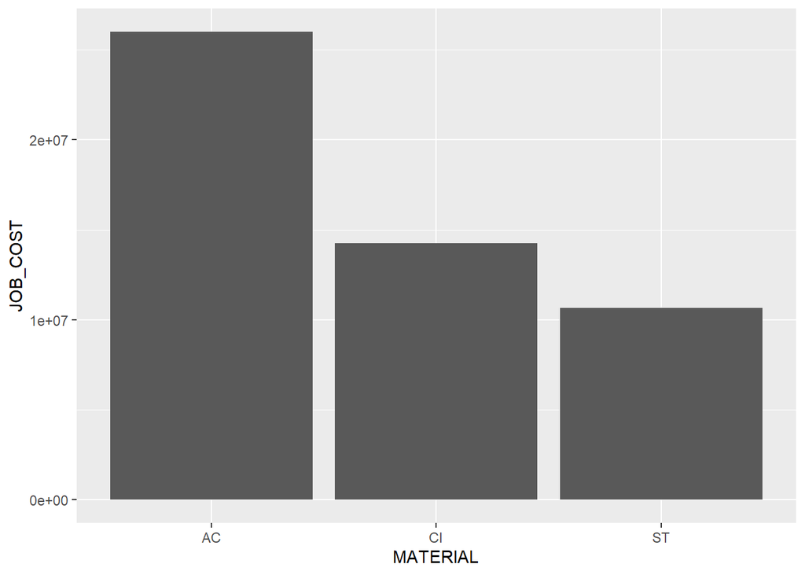

```r
p7 <- ggplot(cleandf, aes(x = MATERIAL, y = JOB_COST)) +
      geom_bar(stat = "identity")
p7
```

# Analysing the data

## Normalise/Standardise the data

Normalising the predictor variables allows for direct comparison of effect size.

```r
#Z transform the continous predictor variables
cleandf$zDEPTH <- (cleandf$DEPTH_M - mean(cleandf$DEPTH_M))/sd(cleandf$DEPTH_M)

cleandf$zDIAMETER <- (cleandf$DIAMETER_MM - mean(cleandf$DIAMETER_MM))/sd(cleandf$DIAMETER_MM)

cleandf$zLENGTH <- (cleandf$LENGTH_M - mean(cleandf$LENGTH_M))/sd(cleandf$LENGTH_M)
#Check variables have been normalised
summary(cleandf)
```

```
##     JOB_ID             JOB_TYPE       DEPTH_M       DIAMETER_MM    MATERIAL
##  Length:4989        Repair :1488   Min.   :1.000   Min.   : 50.0   AC:2554
##  Class :character   Replace:3501   1st Qu.:2.010   1st Qu.: 63.0   CI:1430
##  Mode  :character                  Median :2.570   Median : 90.0   ST:1005
##                                    Mean   :2.673   Mean   :133.1
##                                    3rd Qu.:3.270   3rd Qu.:200.0
##                                    Max.   :4.980   Max.   :450.0
##     LENGTH_M        JOB_COST           zDEPTH          zDIAMETER
##  Min.   : 8.16   Min.   :  586.5   Min.   :-1.9809   Min.   :-0.9330
##  1st Qu.:17.81   1st Qu.: 3979.2   1st Qu.:-0.7850   1st Qu.:-0.7871
##  Median :23.78   Median : 6985.3   Median :-0.1220   Median :-0.4840
##  Mean   :25.13   Mean   :10207.5   Mean   : 0.0000   Mean   : 0.0000
##  3rd Qu.:31.65   3rd Qu.:12884.9   3rd Qu.: 0.7069   3rd Qu.: 0.7509
##  Max.   :49.71   Max.   :85860.1   Max.   : 2.7316   Max.   : 3.5573
##     zLENGTH
##  Min.   :-1.8659
##  1st Qu.:-0.8048
##  Median :-0.1484
##  Mean   : 0.0000
##  3rd Qu.: 0.7170
##  Max.   : 2.7029
```

```r
#Write cleandf
write.table(cleandf, file = paste("cleanData.csv", sep = "/"), sep = ",", row.names = FALSE)
```

## Examine relationships

```r
#Multiple regression analysis
JOB_COSTlm <- lm(JOB_COST ~ zDEPTH + zDIAMETER + zLENGTH + JOB_TYPE, data=cleandf)
#Examine regression analysis
summary(JOB_COSTlm)
```

```
##
## Call:
## lm(formula = JOB_COST ~ zDEPTH + zDIAMETER + zLENGTH + JOB_TYPE,
##     data = cleandf)
##
## Residuals:
##    Min     1Q Median     3Q    Max
## -17563  -1963   -419   1367  40745
##
## Coefficients:
##                 Estimate Std. Error t value Pr(>|t|)
## (Intercept)      4473.51     106.60   41.97   <2e-16 ***
## zDEPTH           3273.35      58.22   56.22   <2e-16 ***
## zDIAMETER        6760.36      58.22  116.12   <2e-16 ***
## zLENGTH          1657.11      58.21   28.47   <2e-16 ***
## JOB_TYPEReplace  8171.03     127.27   64.20   <2e-16 ***
## ---
## Signif. codes:  0 '***' 0.001 '**' 0.01 '*' 0.05 '.' 0.1 ' ' 1
##
## Residual standard error: 4111 on 4984 degrees of freedom
## Multiple R-squared:  0.8143, Adjusted R-squared:  0.8142
## F-statistic:  5465 on 4 and 4984 DF,  p-value: < 2.2e-16
```

```r
#Multiple regression analysis
JOB_COSTlm2 <- lm(JOB_COST ~ zDEPTH + zDIAMETER + zLENGTH + JOB_TYPE + MATERIAL, data=cleandf)
#Examine regression analysis
summary(JOB_COSTlm2)
```

```
##
## Call:
## lm(formula = JOB_COST ~ zDEPTH + zDIAMETER + zLENGTH + JOB_TYPE +
##     MATERIAL, data = cleandf)
##
## Residuals:
##    Min     1Q Median     3Q    Max
## -17583  -1961   -413   1362  40726
##
## Coefficients:
##                 Estimate Std. Error t value Pr(>|t|)
## (Intercept)      4492.57     121.43  36.996   <2e-16 ***
## zDEPTH           3273.32      58.28  56.162   <2e-16 ***
## zDIAMETER        6760.53      58.23 116.097   <2e-16 ***
## zLENGTH          1657.40      58.23  28.461   <2e-16 ***
## JOB_TYPEReplace  8170.40     127.31  64.178   <2e-16 ***
## MATERIALCI        -40.52     135.86  -0.298    0.766
## MATERIALST        -34.74     153.21  -0.227    0.821
## ---
## Signif. codes:  0 '***' 0.001 '**' 0.01 '*' 0.05 '.' 0.1 ' ' 1
##
## Residual standard error: 4112 on 4982 degrees of freedom
## Multiple R-squared:  0.8143, Adjusted R-squared:  0.8141
## F-statistic:  3642 on 6 and 4982 DF,  p-value: < 2.2e-16
```

```r
#Compare models
anova(JOB_COSTlm, JOB_COSTlm2)
```

```
## Analysis of Variance Table
##
## Model 1: JOB_COST ~ zDEPTH + zDIAMETER + zLENGTH + JOB_TYPE
## Model 2: JOB_COST ~ zDEPTH + zDIAMETER + zLENGTH + JOB_TYPE + MATERIAL
##   Res.Df        RSS Df Sum of Sq      F Pr(>F)
## 1   4984 8.4231e+10
## 2   4982 8.4229e+10  2   1831649 0.0542 0.9473
```

## Examine interactions

```r
#Regression analysis including interactions
JOB_COSTlm3 <- lm(JOB_COST ~ zDEPTH + zDIAMETER + zLENGTH + JOB_TYPE + MATERIAL + zDEPTH:JOB_TYPE + zDIAMETER:JOB_TYPE + zLENGTH:JOB_TYPE, data=cleandf)
#Examine regression analysis
summary(JOB_COSTlm3)
```

```
##
## Call:
## lm(formula = JOB_COST ~ zDEPTH + zDIAMETER + zLENGTH + JOB_TYPE +
##     MATERIAL + zDEPTH:JOB_TYPE + zDIAMETER:JOB_TYPE + zLENGTH:JOB_TYPE,
##     data = cleandf)
##
## Residuals:
##    Min     1Q Median     3Q    Max
## -21268  -1245    -53   1081  33776
##
## Coefficients:
##                           Estimate Std. Error t value Pr(>|t|)
## (Intercept)                4420.31      89.25  49.527   <2e-16 ***
## zDEPTH                     1348.17      79.68  16.920   <2e-16 ***
## zDIAMETER                  2973.05      78.97  37.646   <2e-16 ***
## zLENGTH                     740.33      78.56   9.424   <2e-16 ***
## JOB_TYPEReplace            8217.88      93.54  87.850   <2e-16 ***
## MATERIALCI                  -66.28      99.80  -0.664    0.507
## MATERIALST                   73.37     112.57   0.652    0.515
## zDEPTH:JOB_TYPEReplace     2697.75      94.44  28.565   <2e-16 ***
## zDIAMETER:JOB_TYPEReplace  5350.57      93.96  56.947   <2e-16 ***
## zLENGTH:JOB_TYPEReplace    1266.04      93.66  13.517   <2e-16 ***
## ---
## Signif. codes:  0 '***' 0.001 '**' 0.01 '*' 0.05 '.' 0.1 ' ' 1
##
## Residual standard error: 3020 on 4979 degrees of freedom
## Multiple R-squared:  0.8999, Adjusted R-squared:  0.8997
## F-statistic:  4972 on 9 and 4979 DF,  p-value: < 2.2e-16
```

# 3. Prediciting the cost of a job

regression analysis without normalised variables

```r
#Regression analysis predicting job cost
JOB_COSTlm4 <- lm(JOB_COST ~ DEPTH_M + DIAMETER_MM + LENGTH_M + JOB_TYPE + MATERIAL, data=cleandf)
#Examine regression analysis
summary(JOB_COSTlm4)
```

```
##
## Call:
## lm(formula = JOB_COST ~ DEPTH_M + DIAMETER_MM + LENGTH_M + JOB_TYPE +
##     MATERIAL, data = cleandf)
##
## Residuals:
##    Min     1Q Median     3Q    Max
## -17583  -1961   -413   1362  40726
##
## Coefficients:
##                   Estimate Std. Error t value Pr(>|t|)
## (Intercept)     -2.055e+04  2.850e+02 -72.105   <2e-16 ***
## DEPTH_M          3.876e+03  6.901e+01  56.162   <2e-16 ***
## DIAMETER_MM      7.589e+01  6.537e-01 116.097   <2e-16 ***
## LENGTH_M         1.822e+02  6.403e+00  28.461   <2e-16 ***
## JOB_TYPEReplace  8.170e+03  1.273e+02  64.178   <2e-16 ***
## MATERIALCI      -4.052e+01  1.359e+02  -0.298    0.766
## MATERIALST      -3.474e+01  1.532e+02  -0.227    0.821
## ---
## Signif. codes:  0 '***' 0.001 '**' 0.01 '*' 0.05 '.' 0.1 ' ' 1
##
## Residual standard error: 4112 on 4982 degrees of freedom
## Multiple R-squared:  0.8143, Adjusted R-squared:  0.8141
## F-statistic:  3642 on 6 and 4982 DF,  p-value: < 2.2e-16
```

The model explains **81.4%** of variance in the cost of a job. This suggest there are other variables effecting job cost. 81.4% is still a considerable amount of variance explained and so developing an equation to predict job cost may be useful.

### Regression formula

Using the formula for a regression analysis we can create an equation to predict the cost of a job **y = b1 * X1 + b2 * x2 + … + bk * xk + a**

### Formula for the current model

Job Cost = DEPTH_M * DEPTH_M estimate + DIAMETER_MM * DIAMETER_MM estimate + LENGTH_M * LENGTH_M estimate + (1 if JOB_TPYE = replace, if not 0) * JOB_TYPEReplace estimate + (1 if MATERIAL = CI, if not 0) * MATERIALCI estimate + (1 if MATERIAL = ST, if not 0) * MATERIALST estiamte + intercept

### Formula in action

We can use this equation to calculate the job cost of a typical job if the piping company started creating piping in a new larger diameter size of 600mm.

Using values of (mean values used) * DEPTH_M = 2.673 * DIMATER_MM = 600 * LENGTH = 25.13 * JOB_TYPE = Replace * MATERIAL = AC

```r
JobCost = (2.673 * 3876) + (600 * 75.89) + (25.13 * 182.2) + (1 * 8170) + (0 * -40.52) + (0 * -34.74) - 20550

JobCost
```

```
## [1] 48093.23
```